# 1. Acquisition et chargement des données

### 4. Cartes avec les routes d'un ou plusieurs voiliers

```python
# Preperation of dataset for visualizatin of traveled path
route = classement_ensemble[['Skipper','Heure FR','Latitude','Longitude']]
route = route.sort_values(by=['Skipper', 'Heure FR']).reset_index(drop=True)

# make a list of all skipper's names
len = int(route.shape[0] / 32)
N=[]
for i in range(32):
    name = route.iloc[i*len]['Skipper']
    name = str(name).strip().split('\n')[0]
    N.append(name)
```

```python
# visualisation of skipper's path by using ipyplet library

m = Map(center = (0, -17), zoom=2)
colors_list = list(colors._colors_full_map.values())

for i in range(32):
    # put latitude and logitude in a list as couple
    loc = []
    skipper_name = N[i]
    a = route.loc[route['Skipper']==skipper_name]['Latitude']
    b = route.loc[route['Skipper']==skipper_name]['Longitude']
    for n,k in zip(a,b):
        l=[n,k]
        loc.append(l)
    lines = Polyline(locations=[loc], color=colors_list[i], weight=2, fill=False)
    # add marker with name for each skipper
    marker = Marker(location=(loc[-1][0], loc[-1][1]), name=N[i], opacity=0.3)
    m.add_layer(lines)
    m.add_layer(marker)
# add control button on top right of the graph so that we can choose the skipper
control = LayersControl(position='topright')
m.add_control(control)
m
```

[output not shown]

### 5. Analyses de séries temporelles.

```python
# sort the dataframe by date and time with a ascending order
classement_ensemble = classement_ensemble.sort_values(by=['Heure FR'])
```

```python
# visualization of skipper's rank in time series
def plot_rank_time(choose_name):
    plt.figure(1,figsize=(15,10))
    rank_time = classement_ensemble[classement_ensemble['Skipper']==choose_name]['Rang'].values.tolist()
    size = classement_ensemble[classement_ensemble['Skipper']==choose_name]['Rang'].size
    x_name = [i for i in range(size)]
    time_stamp = classement_ensemble[classement_ensemble['Skipper']==choose_name]['Heure FR'].astype(str).tolist()
    plt.plot(x_name, rank_time,label=choose_name)
    l=[i*(size//5) for i in range(5)]
    time_stamp = [time_stamp[i] for i in l]
    plt.xticks(l, time_stamp)
    plt.xlabel('')
    plt.ylabel('rank')
    plt.legend()
    plt.title(f'Evolution of rank for skipper [{choose_name}], from {time_stamp[0]} to {time_stamp[-1]}', fontsize=14);
```

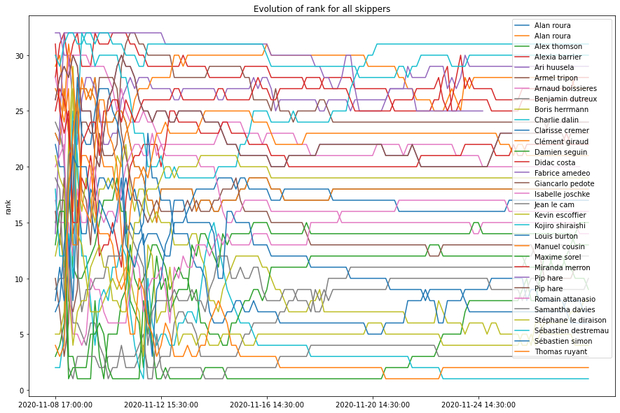

```python
# plot the overall view for all skippers
for name in N:
    plot_rank_time(name)
    plt.title('Evolution of rank for all skippers')
```

#### From the graph, we can say that at the begining, the rank is very unstable and confusing, we couldn't tell whcih skipper is in advantage. Four days after the start of the race, the ranking began to stabilize and there was no major shock.

```
Enter a skipper's name among ['Alan roura', 'Alex thomson', 'Alexia barrier', 'Ari huusela', 'Armel tripon', 'Arnaud boissieres', 'Benjamin dutreux', 'Boris herrmann', 'Charlie dalin', 'Clarisse cremer', 'Clément giraud', 'Damien seguin', 'Didac costa', 'Fabrice amedeo', 'Giancarlo pedote', 'Isabell…
Alan roura
```

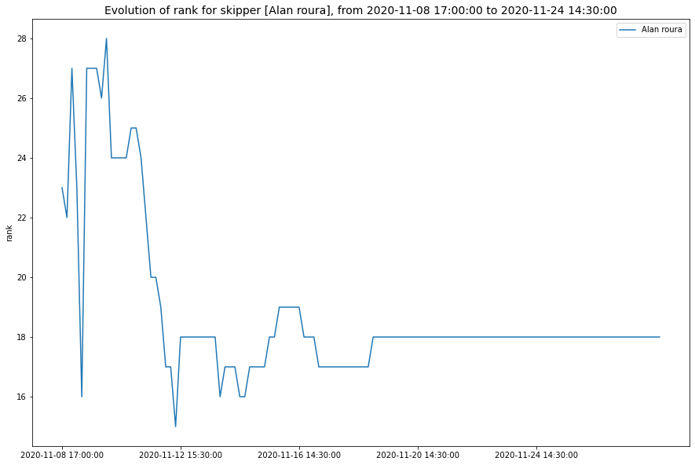

```python
# we add an option to choose the skipper we want to see
choose_name = input(f"Enter a skipper's name among {N}:\n")
plot_rank_time(choose_name)
```

### 6. Application d'algorithmes de machine learning pour prédire le rang

#### In this section, we want to use Lasso linear regression algorithm to select the most important features for the rank. Moreover, we want to see the prediction accuracy obtained by different features.

```python
# This function allows us to convert str to numeric
def to_numeric(df, cols):
    le = LabelEncoder()
    df_copy=df.copy()
    for col in cols:
        df_copy[col] = le.fit_transform(df_copy[col].astype('str'))
    return df_copy
```

```python
# applt function to_numeric to change cols dtypes
cols = ['Nation', 'Déplacement (poids)', 'Nombre de dérives', 'Voile quille', 'Skipper', 'Heure FR','Date de lancement']
df_num = to_numeric(df, cols)
```

**At the beginning, we study the importance of each feature to rank,so we make rank as our target so y and other columns as the features so X. However, some features have the same nature like 'Voile','Numero de voile', and some features don't relate to rank like 'Anciens noms du bateau', so we remove these 'useless' columns from our X.**

```python
# preparation of dataframe X_total which contains nearly all the features in df
cols_drop = ['Nat. / Voile', 'date','Skipper / Bateau', 'Bateau_x', 'Bateau_y',
             'Numéro de voile', 'Anciens noms du bateau', 'Architecte','Chantier', 'Rang']
X_total = df_num.drop(cols_drop, axis=1)
y = df_num[['Rang']].values
X_train,X_test,y_train,y_test = train_test_split(X_total, y, test_size=0.2,random_state=42)
```

```
The optimal regularisation parameter for Lasso is 4.582
R2 score of Lasso is 0.712
Features selected by Lasso are: MultiIndex([(                       'Voile',              ''),
            (           'Depuis 30 minutes',           'Cap'),
            ('Depuis le dernier classement',           'Cap'),
            (            'Depuis 24 heures', 'Distance / nm'),
            (                    'DTF / nm',              ''),
            (                    'DTL / nm',              ''),
            (           'Date de lancement',              ''),
            (   'Surface de voiles au près',              '')],
           )
```

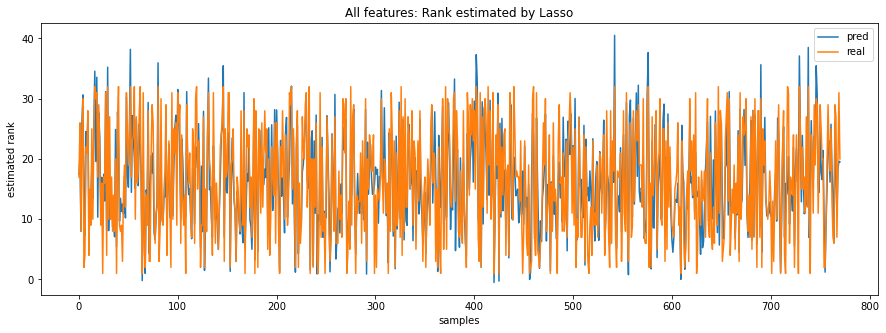

```python
# choose the optimal regularisation parameter for Lasso
lassocv = LassoCV(cv=5)
lassocv.fit(X_train, y_train.ravel())
print("The optimal regularisation parameter for Lasso is", round(lassocv.alpha_, 3))

# Lasso estimator
lasso = Lasso(alpha=lassocv.alpha_)
lasso.fit(X_train, y_train)
print("R2 score of Lasso is", round(r2_score(y_test, lasso.predict(X_test)), 3))

# feature selected by Lasso: coefficients is not null
lasso_var = np.where(lasso.coef_ != 0)[0]
print(f"Features selected by Lasso are:", X_total.columns[lasso_var])

# visualization of the results
plt.figure(figsize=(15,5))
plt.plot(lasso.predict(X_test), label='pred')
plt.plot(y_test, label='real')
plt.xlabel('samples')
plt.ylabel('estimated rank')
plt.legend()
plt.title('All features: Rank estimated by Lasso')
plt.legend();
```

**Moreover, we want to study if the structure of the boat will influence the results of competition. So now we will use purely the features provided by df_technique to see their relationship.**

```python
# preperation of new dataset provided by technic document df_technique
X = df_num[['Déplacement (poids)',
            'Nombre de dérives', 'Voile quille','Longueur',
            'Largeur',"Tirant d'eau", 'Hauteur mât','Surface de voiles au près',
           'Surface de voiles au portant', 'Date de lancement']]

X_train,X_test,y_train,y_test = train_test_split(X, y, test_size=0.2,random_state=42)
```

```
The optimal regularisation parameter for Lasso is 0.098
R2 score of Lasso is 0.35
Features selected by Lasso are: MultiIndex([(         'Déplacement (poids)', ''),
            (           'Nombre de dérives', ''),
            (                'Voile quille', ''),
            (                     'Largeur', ''),
            (                 'Hauteur mât', ''),
            (   'Surface de voiles au près', ''),
            ('Surface de voiles au portant', ''),
            (           'Date de lancement', '')],
           )
```

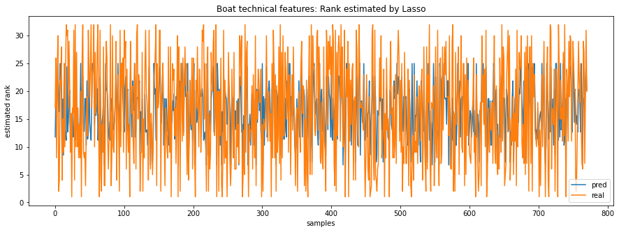

```python
# choose the optimal regularisation parameter for Lasso
lassocv = LassoCV(cv=5)
lassocv.fit(X_train, y_train.ravel())
print("The optimal regularisation parameter for Lasso is", round(lassocv.alpha_, 3))

# Lasso estimator
lasso = Lasso(alpha=lassocv.alpha_)
lasso.fit(X_train, y_train)
print("R2 score of Lasso is", round(r2_score(y_test, lasso.predict(X_test)), 3))

# feature selected by Lasso: coefficients is not null
lasso_var = np.where(lasso.coef_ != 0)[0]
print(f"Features selected by Lasso are:", X.columns[lasso_var])

# visualization of the results
plt.figure(figsize=(15,5))
plt.plot(lasso.predict(X_test), label='pred')
plt.plot(y_test, label='real')
plt.xlabel('samples')
plt.ylabel('estimated rank')
plt.title('Boat technical features: Rank estimated by Lasso')
plt.legend();
```

**Knowing that best possible R2 score is 1.0, so closer R2 score to 1.0, better our estimator is. In our case,we only used the information about the boat but not the race, we already obtained an estimator with R2=0.0.35. Moreover, thanks to the characteristics of Lasso estimator, il allows exsitence of null coefficients for some features, so that we can find more meaningful features to predict rank. Here we found *Deplacement, nombre de derive, voile quile, largeur, hauteur de mat, surface de voile pres, surface de voile au portant, date de lancement* are the most important features to rank. Surprisingly, we could say that the boat structure influnce not bad the skipper's rank. So in order to have a better rank in the competition, skipper can ameliorate their boat structure.**

## Conclusion

```python
Récupération des fichiers Excel avec les classements.
Extraction des fiches techniques pour chacun des voiliers.
Rapprochement des données des voiliers avec celle des classements.
Corrélation et régression linéaire entre le classement (rang) et la vitesse utile (VMG) des voiliers.
Impact de la présence d'un foil sur le classement et la vitesse des voiliers.
Visualisation de la distance parcourue par voilier.
Cartes avec les routes d'un ou plusieurs voiliers selon diverses projections (cylindrique équidistante, sinusoïdale, ...).
Analyses de séries temporelles.
Application d'algorithmes statistiques ou de machine learning.
```

### In this project, we collected and scrapped data from website, a pre-processing allows to have a cleaner dataset. As for analysis part, we proved that rank and VMG have a negative relation. Existance of foil improved the rank and VMG of skipper. Moreover, we visualized the traveled distance and map by skipper. A time series skipper's rank analysis is performed in order to study the relationship between time and rank, we constate that rank stabilized 4 days after the start of race. Finally, using Lasso algorithm helped us to find out the most important features in the race. Suprisingly, we found that information about boat is an important factor for the rank.